# Part I - ( Loan Data from prosper Exploration)

## by Bernice Akinwande

## Introduction

> This data set contains 113,937 loans with 81 variables on each loan, including loan amount, borrower rate (or interest rate), current loan status, borrower income, and many others.

## Preliminary Wrangling

### What is the structure of your dataset?

> This data set contains 113,937 loans with 81 variables on each loan.

### What is/are the main feature(s) of interest in your dataset?

> The main feature of interest is The Borrower's APR that will be analyzied with many factors like the borrower's rating, score, occupation and income that could influence change in borrower's APR.

### What features in the dataset do you think will help support your investigation into your feature(s) of interest?

> The Prosper Rating and score could show low Borrower's APR because higher rating reflect the borrower's personality to be more trustworthy. Creditscore could also have similar effect on Borrower's APR as Prosper Rating.

## Univariate Exploration

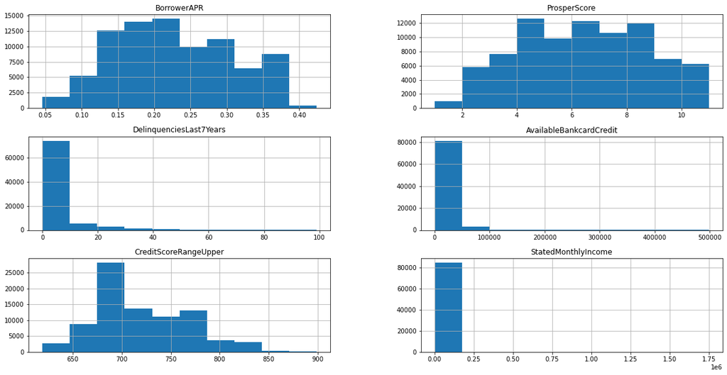

```python
#lets get a general overview of some numerical variable columns we would be exploring
#in the  data set with an histogram
sample_variables = ['BorrowerAPR', 'ProsperScore', 'DelinquenciesLast7Years', 'AvailableBankcardCredit', 'CreditScoreRangeUpper', 'StatedMonthlyIncome']
df_new_loan[sample_variables].hist(xlabelsize= 10,figsize= [20,10]);
```

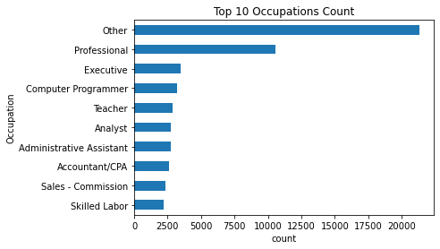

```python
#to find the top 10 occupations of borrowers
#define a function for scatter plot to avoid writing repeatitive codes
def plot_scatter(a,b,c):
    plt.scatterplot(x=a, y=b, data=c)
    plt.figsize=(12,12)
    plt.fontsize = 12

df_new_loan['Occupation'].value_counts()[9::-1].plot(kind='barh')
plt.title('Top 10 Occupations Count')
plt.xlabel('count')
plt.ylabel('Occupation');
```

#### The Top 10 Occupations Count shows that most borrowers have their occupations as "others" followed by "professional" and this might be because they probably did not want to details on their occupation, so they picked "others". The other occupations have little difference between them compared to the "others" and "proffessional" occupation. The essence of this visualisation is to find out the top occupation of most borrowers.